# Ecological Models and Data Analysis – Chapter 1 — Ecological Models and Data Analysis

## Ecological Models and Data Analysis

Chapter 1 · Lecture

Introduction and Course Overview

## Overview of the lecture

1. **Research questions and models:** what do we want to know?
2. **The modeling cycle:** how do we integrate models and data?
3. **Variation, noise, stochasticity:** why do we need probability?
4. **Estimates and uncertainty:** what can we learn from data?
5. **The course and the practical:** what comes next?

## The problem and the purpose of the course

### The problem

- Ecological models: little data.
- Experiments: standard statistics.
- Real data: curved responses, not Normal, unbalanced.

### This course

- Combine ecological models and statistics.
- **Likelihood-based inference**.
- **Non-linear mixed models**.

The aim: an answer to an ecological question.

## Ecological questions

| Yes or no? | How much? What shape? |
| --- | --- |
| Does temperature affect development? | How does development change with temperature? Is there an optimum? |
| Does a treatment affect seedling survival? | How much does survival change? |

Question $\rightarrow$ Model: To answer my question, I need to estimate…

**30 seconds:** make “Does food availability affect growth?” more specific.

## A predator’s feeding response

[figure not shown]

- **Straight line:** keeps increasing.
- **Saturating curve:** limited by search and handling time.
- **Parameters:** the maximum, the rate at low density.
- **Answers:** compare parameters across sites, species, treatments…

Questions $\rightarrow$ Models $\rightarrow$ Parameters $\rightarrow$ Answers

## The components of a statistical model

**Model:** a mathematical simplification of the process that generates the data.

[figure not shown]

### Response function

The expected response: the curve.

### Probability distribution

The variation around it: the scatter.

## The modelling cycle

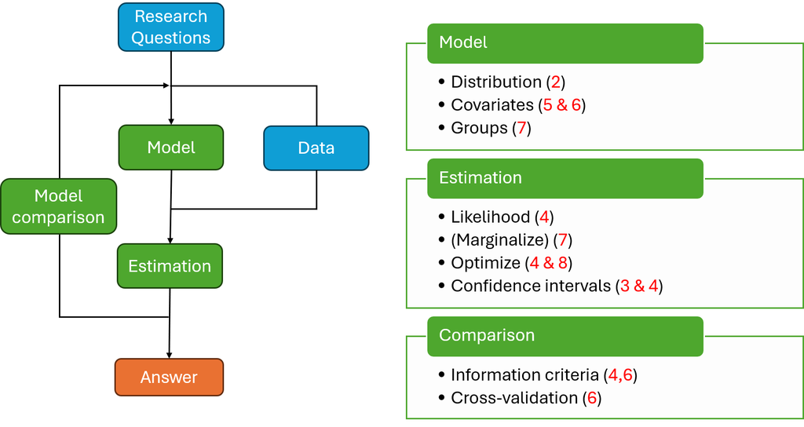

Red numbers: chapters of the course.

## Observation error and process variation

### Observation error

What we record differs from what happens.

- Individuals missed or counted twice.
- Imperfect instruments.
- Protocol differences.

20 insects on a plant, 16 recorded.

### Process variation

Real variation that the model does not explain.

- Environment, unmeasured drivers.
- Individual differences.
- Chance in births and deaths.
- Clusters and nested groups.

If we counted every insect perfectly, would all plants have the same count?

## Probability models for ecological observations

### Insect counts

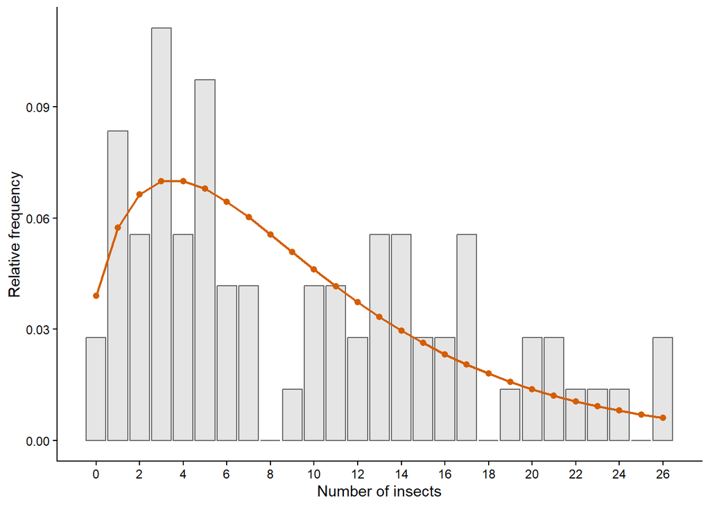

Counts: 0, 1, 2, … · **Negative Binomial**

### Animal body masses

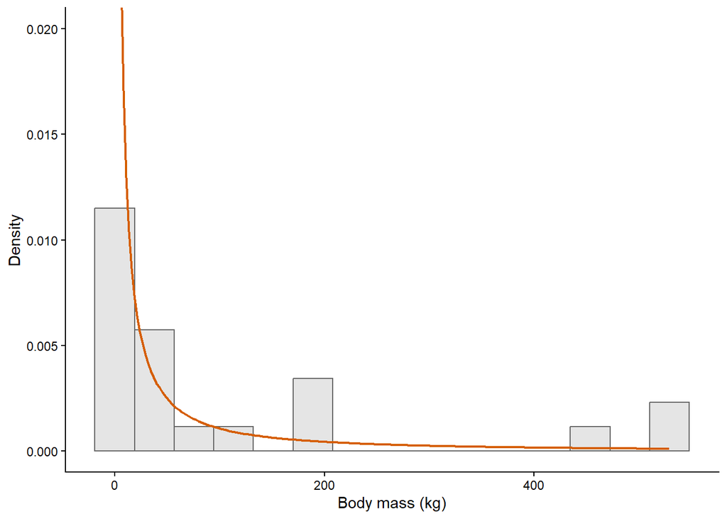

Positive, continuous · **LogNormal**

Grey: observations. Orange: fitted model.

## Explaining some of the variation

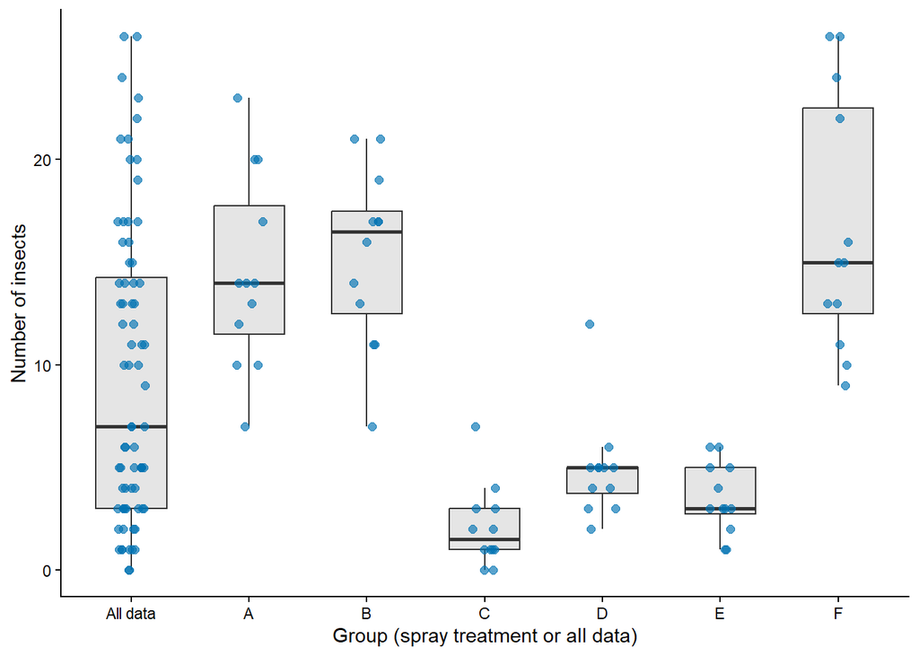

**The same counts, by spray**

- All data: Obs error + Process var.
- Among sprays: Process variation.
- Within spray: Obs error + Process var.

What do we lose when we put every count in one group?

## Parameters and estimates

**Parameter:** a quantity that sets a feature of the model.

- A mean count.
- A probability of survival.
- A maximum feeding rate.

**Estimate:** its value, calculated from the data.

**Uncertainty:** variation in estimates, lack of perfect knowledge.

## Parameter uncertainty

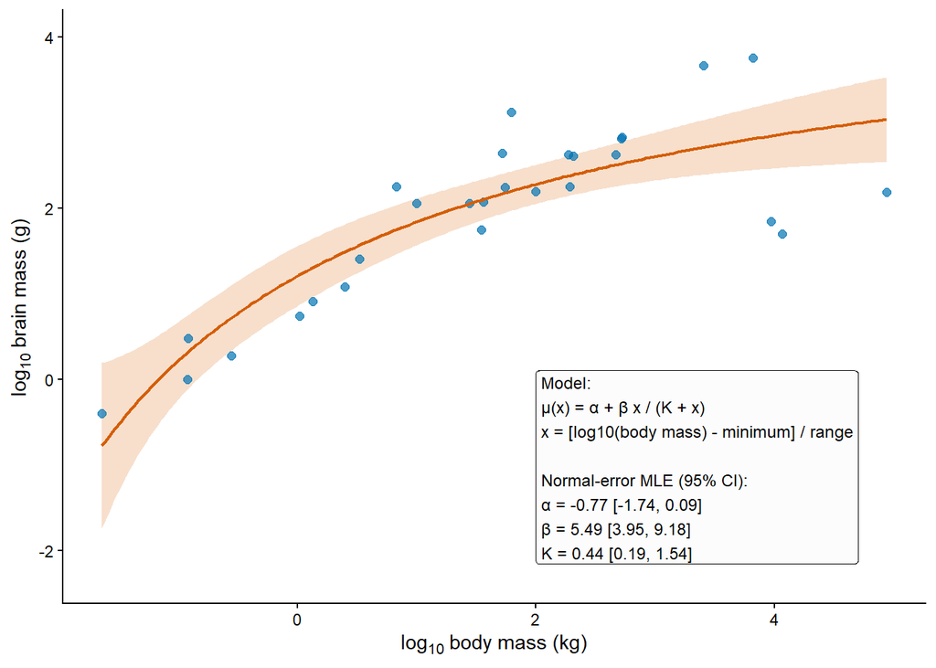

- Several curves are compatible with the data because…
  - Observation error
  - Process variation
  - Model approimation.
- Consequence: parameter and prediction uncertainty.
- Probability also models uncertainty!

Points: species. Line: fitted curve. Band: uncertainty.

## Discussion: which source of variation?

1. Two observers, the same animals, different counts.
2. Two plants, the same spray, different true counts.
3. Another sample, a different estimate.

Observation error · Process variation · Parameter uncertainty

**30 seconds:** discuss with a neighbour.

## Reality, model and data

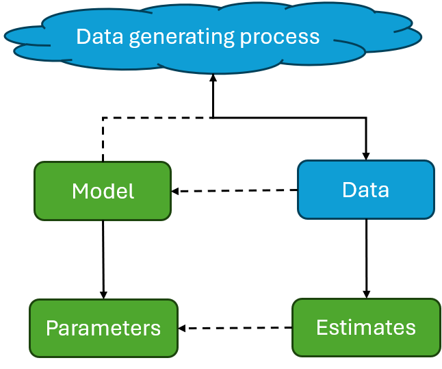

**Solid arrows:** derived.

**Dashed arrows:** assumed, approximate.

We treat the data as if they were a random sample from the model.

## What we want from a statistical analysis

- How large is the response? What shape?
- How uncertain are the estimates of the parameters?
- Which model describes the data better?
- How well does the model fit the data?

A small p-value is not the goal of an analysis.

## Course roadmap: from distributions to estimation

| Chapter | Main question |
| --- | --- |
| **1. Ecological models and data** | How do questions, models and data connect? |
| **2. Probability distributions** | What can we observe, and how probable is it? |
| **3. From samples to estimates** | What does a sample tell us? |
| **4. Maximum likelihood estimation** | How do we estimate, and how uncertain are we? |

## Course roadmap: response curves to optimisation

| Chapter | Main question |
| --- | --- |
| **5. Deterministic functions in ecology** | Which curves describe ecological responses? |
| **6. Fitting ecological response curves** | How do we fit a curve to data? |
| **7. Grouped ecological response curves** | How do groups differ? |
| **8. Numerical optimisation** | What if a fit is difficult? |

## The Chapter 1 R practical

- **Scripts and projects:** reproducible work.
- **Vectors, matrices, lists, data frames:** store data and results.
- **Plots:** look at data and models.
- **Functions and loops:** write models, repeat calculations.
- **AI as a tutor:** try first, then ask.

Run the examples. Try the exercises. Explain your results.

## Summary and closing questions

- The question and data guides the model.
- Probability describes observation error and process variation.
- Estimates come with uncertainty.
- Fitting, comparing and checking form a cycle.

Question · Model · Data · Estimation · Comparison · Answer

**Closing questions**

1. Why does a feeding curve need a probability model?
2. Variation among observations and uncertainty about a parameter: what is the difference?